# Assignment 5: Using Sobol with an ODE solver

## Taylor Cook

### 2025-05-12

Consider the following model of forest growth (where forest size in measured units of carbon (C))

1. dC/dt = r * C (for forests where C is below threshold canopy cover)
2. dC/dt = g * (1 - C/K) (for forests where carbon is at or above the threshold canopy closure)

## Question 1: Implement model in R as a differential equation

```r
source(here("R/forestgrowth.R"))
dforestgrowth
```

```
## function (time, C, params)
## {
##     with(as.list(c(C, params)), {
##         if (C < Cthresh) {
##             dCdt <- r * C
##         }
##         else {
##             dCdt <- g * (1 - C/K)
##         }
##         return(list(dCdt))
##     })
## }
```

## Question 2: Run the model for 300 years (using ODE solver) starting with an initial forest size of 10 kg/C, and using the following parameters:

1. K = 250 kg C
2. r = 0.01 kg C/year
3. g = 2 kg C/year
4. canopy closure threshold of 50kgC

```r
# recall ODE needs ALL of our parameters in a single list
# initial population and times for which we want output
Cinitial <- 10 #intital forest size

# gets results for 300 years (evaluating every year)
simtimes_plot <- seq(from = 1, to = 300)
parms_plot <- list(r = 0.01, K=250, g=2, Cthresh=50)

result_plot <- ode(y = Cinitial, times = simtimes_plot, func = dforestgrowth, parms = parms_plot)

head(result_plot)
```

```
##      time        1
## [1,]    1 10.00000
## [2,]    2 10.10050
## [3,]    3 10.20202
## [4,]    4 10.30455
## [5,]    5 10.40811
## [6,]    6 10.51271
```

```r
colnames(result_plot) <- c("time", "C")

# turn it into a data frame
ode_result_plot <- as.data.frame(result_plot)
```

## Question 3: Plot the results of the simulation

Graphing the trajectory with the parameters as given (no uncertainty)

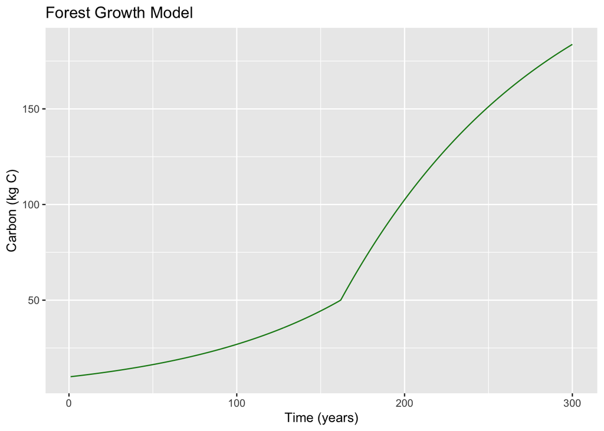

```r
#plot
ggplot(ode_result_plot, aes(time, C)) +
  geom_line(col="forestgreen") +
  labs(title = "Forest Growth Model", x = "Time (years)", y = "Carbon (kg C)")
```

## Question 4: Run a Sobol global (vary all parameters at the same time) sensitivity that explores how the estimated *maximum forest size* (i.e. max of C 300 years, varies with these parameters):

1. pre canopy closure growth rate (r)
2. post canopy closure growth rate (g)
3. canopy closure threshold and carrying capacity (K)

Parameters are normally distributed with means as given above and sd of 10% of mean value

```r
# come up with first set of sample parameters
# we will assume that we know the initial population,
# sobel needs TWO samples of paramets (i.e X1 and X2)

Cintial <- 10 #intital forest size

# set the number of parameters
np <- 2000
K <- rnorm(mean = 250, sd = 0.1*250, n = np)
r <- rnorm(mean = 0.01, sd = 0.1*0.01, n = np)
g<- rnorm(mean = 2, sd = 0.1*2, n = np)
Cthresh <- rnorm(mean = 50, sd = 0.1*50, n = np)
X1 <- cbind.data.frame(r = r, K = K, g = g, Cthresh = Cthresh)

# repeat to get our second set of samples
K <- rnorm(mean = 250, sd = .1*250, n = np)
r <- rnorm(mean = 0.01, sd = .1*.01, n = np)
g<- rnorm(mean = 2, sd = .1*2, n = np)
Cthresh <- rnorm(mean = 50, sd = .1*50, n = np)
X2 <- cbind.data.frame(r = r, K = K, g = g, Cthresh = Cthresh)

# fix any negative values and they are not meaningful
X1 <- X1 %>% map_df(pmax, 0.0)
X2 <- X2 %>% map_df(pmax, 0.0)

# create our sobel object and get sets of parameters for running the model
sens_F <- sobolSalt(model = NULL, X1, X2, nboot = 300)

# our parameter sets are
head(sens_F$X)
```

```
##             [,1]     [,2]     [,3]     [,4]
## [1,] 0.010669320 268.7660 1.932333 49.89246
## [2,] 0.011054285 278.1053 2.082008 48.84369
## [3,] 0.011100365 223.7969 1.735699 48.92585
## [4,] 0.009344589 233.2117 1.951627 51.07387
## [5,] 0.011718926 300.0210 1.865634 50.48089
## [6,] 0.009174064 256.3564 2.066060 39.64471
```

```r
# add names
colnames(sens_F$X) <- c("r", "K", "g", "Cthresh")

head(sens_F$X)
```

```
##                r        K        g  Cthresh
## [1,] 0.010669320 268.7660 1.932333 49.89246
## [2,] 0.011054285 278.1053 2.082008 48.84369
## [3,] 0.011100365 223.7969 1.735699 48.92585
## [4,] 0.009344589 233.2117 1.951627 51.07387
## [5,] 0.011718926 300.0210 1.865634 50.48089
## [6,] 0.009174064 256.3564 2.066060 39.64471
```

```r
# view the first parameter set
sens_F$X[1, ]
```

```
##            r            K            g      Cthresh
##   0.01066932 268.76598227   1.93233279  49.89246465
```

```r
####################################

#Run ODE

# ODE needs ALL of our parameters in a single list
# initial population and times for which we want output
Cinitial <- 10

# gets results for 300 years (evaluating every year)
simtimes <- seq(from = 1, to = 300)
parms <- list(r = sens_F$X[1, "r"],
              K = sens_F$X[1, "K"],
              g = sens_F$X[1, "g"],
              Cthresh = sens_F$X[1, "Cthresh"] )

result <- ode(y = Cinitial, times = simtimes, func = dforestgrowth, parms = parms)

head(result)
```

```
##      time        1
## [1,]    1 10.00000
## [2,]    2 10.10727
## [3,]    3 10.21568
## [4,]    4 10.32526
## [5,]    5 10.43601
## [6,]    6 10.54795
```

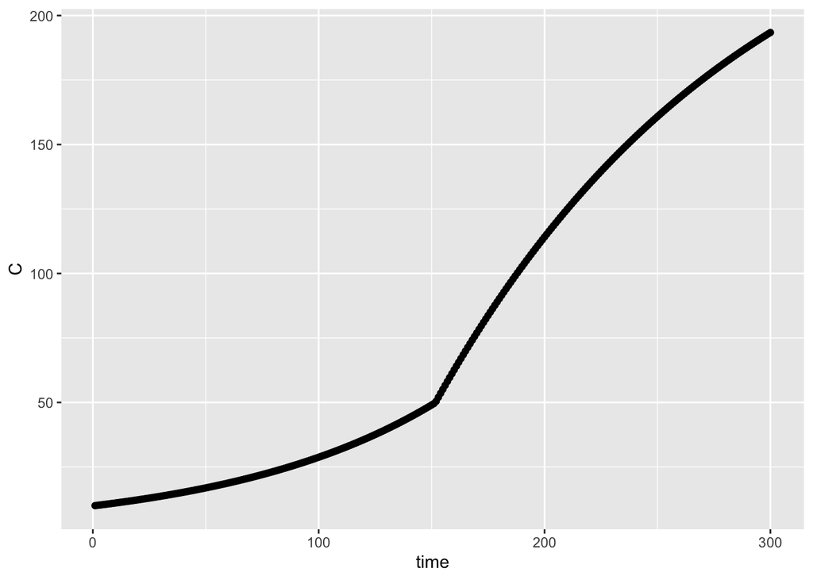

```r
colnames(result) <- c("time", "C")
# turn it into a data frame
result <- as.data.frame(result)
ggplot(result, aes(time, C)) +
  geom_point()
```

```r
# extra our metrics of interest  from this
# maximum population it gets to
maxC <- max(result$C)
maxC
```

```
## [1] 193.4361
```

```r
##########################

# create function for calculating metrics for all parameters
# computing our metrics into a function

compute_metrics <- function(result) {
  maxC <- max(result$C)
 return(list(maxC = maxC))
}

compute_metrics(result)
```

```
## $maxC
## [1] 193.4361
```

```r
############################

# need to apply the ode and this function for all of our parameters
# define a wrapper function to do everything we need - run solver and compute metrics - and send back results for each parameter

# lets make the threshold 90% of carrying capacity

c_wrapper <- function(r, K, g, Cthresh, Cinitial, simtimes, odefunc, metricfunc) {
  parms <- list(r = r, K = K, g = g, Cthresh = Cthresh)
  result <- ode(y = Cinitial, times = simtimes, func = odefunc, parms = parms, method="euler")
  colnames(result) <- c("time", "C")
  # get metrics
  metrics <- metricfunc(as.data.frame(result))
  return(metrics)
}

# test
c_wrapper(
  r = 0.01, K = 250, g = 2, Cthresh = 50, Cinitial = 10, simtimes = seq(from = 1, to = 300),
  odefunc = dforestgrowth, metricfunc = compute_metrics
)
```

```
## $maxC
## [1] 183.4948
```

```r
##########################


# Run wrapper function for all parameters

# now use pmap as we did before

allresults <- as.data.frame(sens_F$X) %>% pmap(c_wrapper, Cinitial = Cinitial, simtimes = simtimes, odefunc = dforestgrowth, metricfunc = compute_metrics)

# extract out results from pmap into a data frame
allres <- allresults %>% map_dfr(`[`, c("maxC"))

# organize said dataframe
allres_organized <- allres %>% pivot_longer(cols = everything(), names_to = "metric", values_to = "value")
```

## Question 5: Graph the results of the sensitivity analysis as a box plot of maximum forest size and record the two Sobel indices (S and T)

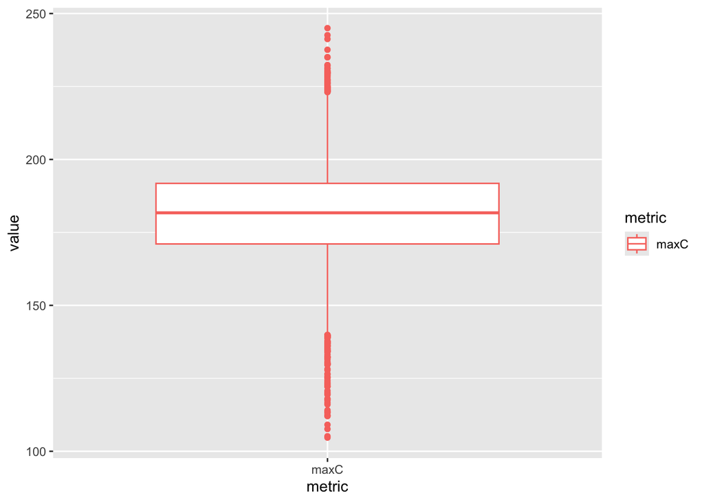

```r
# create boxplots

ggplot(allres_organized, aes(metric, value, col = metric)) +
  geom_boxplot()
```

```r
############################

#Compute Sobol indices
# if 0 is in the confidence interval, the result is not sensitive to this parameter
# r doesn't matter on its own (0 in conf interval), but r matters when we account for interactions with K
#larger indices/orginal = stronger effect

# sobol can only handle one output at a time  - so we will need to do them separately

sens_F_maxC <- sensitivity::tell(sens_F, allres$maxC)

# first-order indices (main effect without co-variance)
rownames(sens_F_maxC$S) <- c("r", "K", "g", "Cthresh")
sens_F_maxC$S
```

```
##          original          bias std. error  min. c.i. max. c.i.
## r       0.3869867 -4.314066e-05 0.02091073 0.34339255 0.4263837
## K       0.3323834  4.066617e-04 0.02296007 0.29191781 0.3782984
## g       0.2088089  9.364627e-04 0.02196210 0.16502538 0.2528294
## Cthresh 0.0785124  2.407575e-04 0.02222722 0.03281942 0.1227270
```

```r
# total sensitivity index -note that this partitions the output variance
rownames(sens_F_maxC$T) <- c("r", "K", "g", "Cthresh")
sens_F_maxC$T
```

```
##           original          bias  std. error  min. c.i.  max. c.i.
## r       0.38937249 -0.0003657453 0.017094458 0.35671001 0.42531188
## K       0.33344888  0.0003980584 0.015817147 0.30157903 0.36490723
## g       0.21550511  0.0005364029 0.010985259 0.19179324 0.23486524
## Cthresh 0.06929428  0.0002850353 0.003737969 0.06128306 0.07682666
```

```r
#combine into one dataframe
sens_F_maxC_df <- data.frame(
  Parameter = c("r", "K", "g", "Cthresh"),
  S = sens_F_maxC$S,
  T = sens_F_maxC$T
)
```

## Question 6: In 2-3 sentance, discuss what the results of your simulation might mean. (For example think about how what parameters climate change might influence)

The results of the Sobol sensitivity analysis indicate that the maximum forest size is most sensitive to the pre-canopy closure growth rate (r) and the carrying capacity (K), with the post-canopy closure growth rate (g) having a moderate influence, and the canopy closure threshold (Cthresh) contributing the least. This suggests that climate change factors affecting r and K, such as temperature and precipitation patterns influencing seedling growth and ecosystem capacity, could significantly impact forest growth and carbon sequestration potential, while changes in g and Cthresh may have a smaller overall effect on forest dynamics.